# **Course Project**

It is now possible to collect large amount of data about personal movement using activity monitoring devices such as Fitbit, Nike Fuelband or Jawbone Up. These type of devices are part of the “quantified self” movement – a group of enthusiasts who take measurements about themselves regularly to improve their health, to find patterns in their behavior, or because they are tech geeks. But these data remain under-utilized both because the raw data are hard to obtain and there is a lack of statistical methods and software for processing and interpreting the data.

This assignment makes use of data from a personal activity monitoring device. This device collects data at 5 minute intervals through out the day. The data consists of two months of data from an anonymous individual collected during the months of October and November, 2012 and include the number of steps taken in 5 minute intervals each day.

# *Loading Packages and the Data*

The first step is to load all the required packages and then load the ‘activity.csv’ file into R Studio.

```r
library(dplyr)
```

```r
library(ggplot2)
library(data.table)
library(timeDate)
library(mlr)
my_data <- read.csv('activity.csv')
```

# *Total Steps taken each day*

The first step is to convert the ‘date’ column from character to actual date type so that inferences could be made.

```r
my_data$date <- strptime(my_data$date, '%Y-%m-%d')
my_group <- group_by(my_data, date)
my_summary <- summarise(my_group, total = sum(steps, na.rm = TRUE))
```

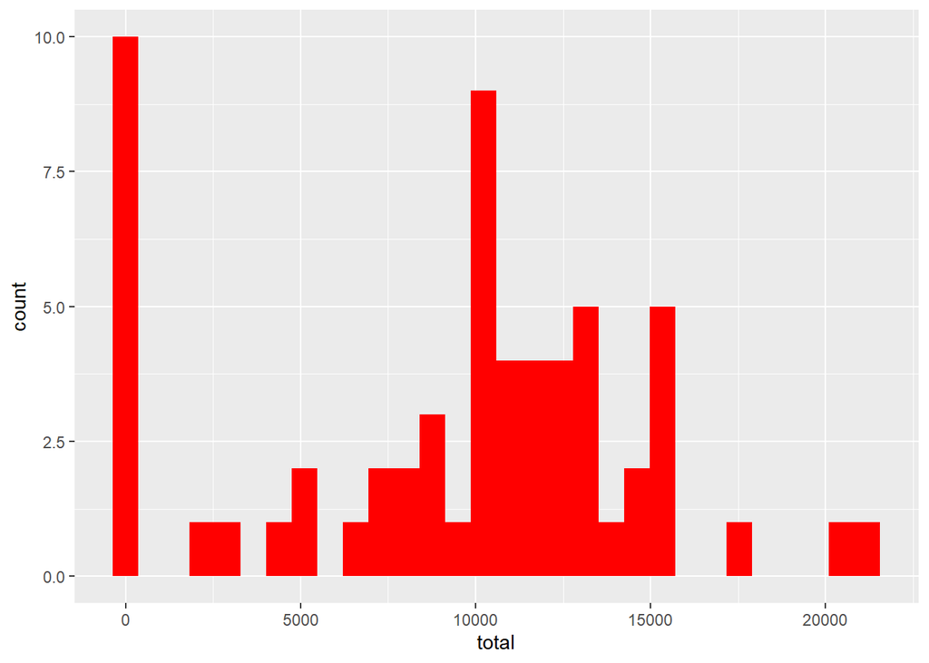

```r
g <- ggplot(my_summary, aes(total))
g + geom_histogram(fill = 'red', bins =30)
```

# *Mean and Median Number of Steps taken each day*

```r
mean_steps <- summarise(my_summary, myMean =mean(total, na.rm = TRUE))
median_steps <- summarise(my_summary, myMedian = median(total, na.rm = TRUE))
mean_steps$myMean
```

```
## [1] 9354.23
```

```r
median_steps$myMedian
```

```
## [1] 10395
```

# *Time series plot of the average number of steps taken*

```r
my_group_2 <- group_by(my_data, interval)
my_summary_2 <- summarise(my_group_2, mean = mean(steps, na.rm =TRUE))
```

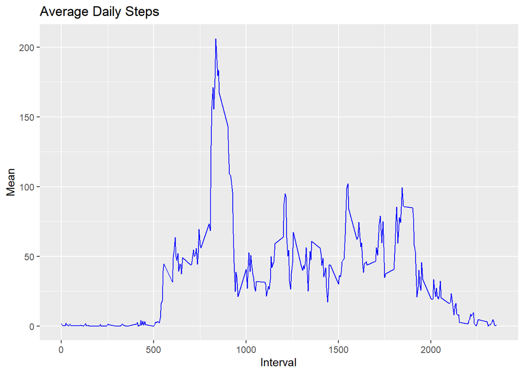

```r
g <- ggplot(my_summary_2, aes(interval, mean))
g + geom_line(color = 'blue') + labs(x = 'Interval', y = 'Mean',
                                     title = 'Average Daily Steps')
```

# *The 5 Minute Interval that contains the maximum number of steps*

```r
my_summary_2[which.max(my_summary_2$mean),]$interval
```

```
## [1] 835
```

# *Imputing missing data and Histogram of steps taken each day with imputed data included*

```r
activityDT <- data.table::fread(input = "activity.csv")
nrow(activityDT[is.na(steps),])
```

```
## [1] 2304
```

```r
activityDT[is.na(my_data$steps), "steps"] <- activityDT[, c(lapply(.SD, median, na.rm = TRUE)), .SDcols = c("steps")]
data.table::fwrite(x = activityDT, file = "tidyData.csv", quote = FALSE)
Total_Steps <- activityDT[, c(lapply(.SD, sum)), .SDcols = c("steps"), by = .(date)]
Total_Steps[, .(Mean_Steps = mean(steps), Median_Steps = median(steps))]
```

```
##    Mean_Steps Median_Steps
## 1:    9354.23        10395
```

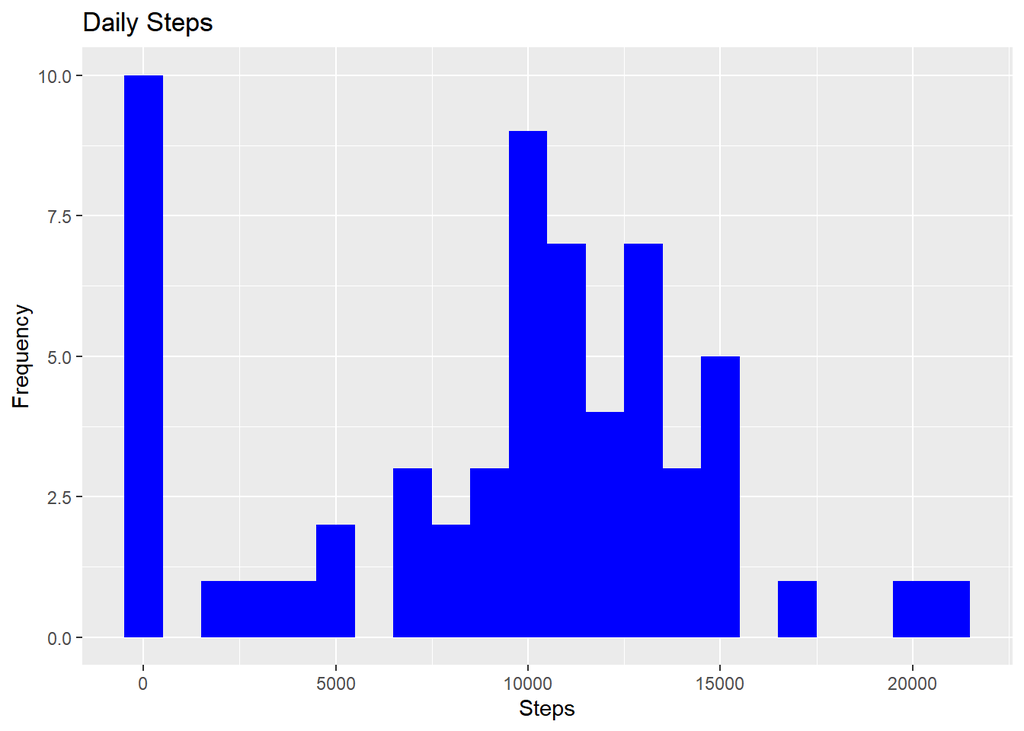

```r
ggplot(Total_Steps, aes(x = steps)) + geom_histogram(fill = "blue", binwidth = 1000) + labs(title = "Daily Steps", x = "Steps", y = "Frequency")
```

# *Panel plot Comparing Steps/5 min interval across weekdays and weekends*

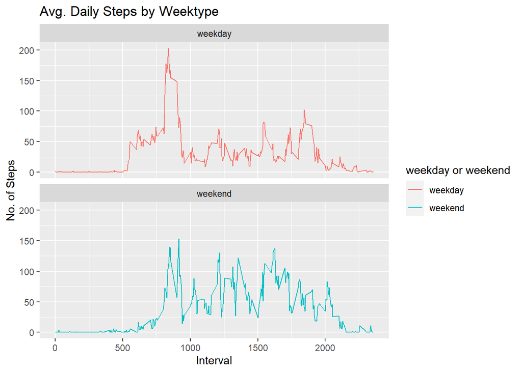

```r
ctivityDT <- data.table::fread(input = "activity.csv")
activityDT[, date := as.POSIXct(date, format = "%Y-%m-%d")]
activityDT[, `Day of Week`:= weekdays(x = date)]
activityDT[grepl(pattern = "Monday|Tuesday|Wednesday|Thursday|Friday", x = `Day of Week`), "weekday or weekend"] <- "weekday"
activityDT[grepl(pattern = "Saturday|Sunday", x = `Day of Week`), "weekday or weekend"] <- "weekend"
activityDT[, `weekday or weekend` := as.factor(`weekday or weekend`)]
activityDT[is.na(steps), "steps"] <- activityDT[, c(lapply(.SD, median, na.rm = TRUE)), .SDcols = c("steps")]
IntervalDT <- activityDT[, c(lapply(.SD, mean, na.rm = TRUE)), .SDcols = c("steps"), by = .(interval, `weekday or weekend`)]

ggplot(IntervalDT , aes(x = interval , y = steps, color=`weekday or weekend`)) + geom_line() + labs(title = "Avg. Daily Steps by Weektype", x = "Interval", y = "No. of Steps") + facet_wrap(~`weekday or weekend` , ncol = 1, nrow=2)
```